# Predict Quality of Weight Lifting

Ranga

August 23, 2015

This is a project to predict How well a weight lifting excercise has been done as opposed to How long it has been done. The emphasis is more on the quality rather then the quantity.

We begin by reading the data and extracting parameters relevent to acceleration only.

```r
library(caret)
library(randomForest)
library(party)
library(rpart)

initD <- read.csv("pml-training.csv")
accelNames <- grep("accel_", names(initD))
```

Then do preprocessing to facilitate learning

```r
# add 'classe' field in column 160 to the data
accelNames <- c(accelNames, 160)
baseD <- initD[, accelNames]

# remove fields which have NA
naFields <- grep("var_", names(baseD))
baseD <- baseD[,-naFields]
```

Split the data set for testing

```r
# slice data
inTrain <- createDataPartition(y=baseD$classe, p=0.7, list=FALSE)
trainD <- baseD[inTrain,]
testingD <- baseD[-inTrain,]

dim(trainD); dim(testingD)
```

```
## [1] 13737    17
```

```
## [1] 5885   17
```

```r
paramD <- trainD
testParamD <- testingD
```

We will build the models the following algorithms: 1) Decision Tree 2) bagging 3) random forest

# Decision Tree Algo

We will build the decision tree model using method=“rpart” in caret package.

```r
# model using decision tree
modFit <-train(classe ~ .,method="rpart",data=paramD)
print(modFit$finalModel)
```

```
## n= 13737
##
## node), split, n, loss, yval, (yprob)
##       * denotes terminal node
##
##  1) root 13737 9831 A (0.28 0.19 0.17 0.16 0.18)
##    2) accel_belt_z>=-187.5 12994 9094 A (0.3 0.2 0.18 0.17 0.14)
##      4) accel_arm_x< -270.5 2207  805 A (0.64 0.12 0.13 0.048 0.068) *
##      5) accel_arm_x>=-270.5 10787 8289 A (0.23 0.22 0.2 0.2 0.15)
##       10) accel_dumbbell_x< 38.5 9903 7440 A (0.25 0.2 0.21 0.21 0.13)
##         20) accel_forearm_x>=-98.5 5650 3983 A (0.3 0.23 0.24 0.1 0.13) *
##         21) accel_forearm_x< -98.5 4253 2725 D (0.19 0.16 0.17 0.36 0.13) *
##       11) accel_dumbbell_x>=38.5 884  426 B (0.04 0.52 0.02 0.049 0.37) *
##    3) accel_belt_z< -187.5 743    7 E (0.0081 0.0013 0 0 0.99) *
```

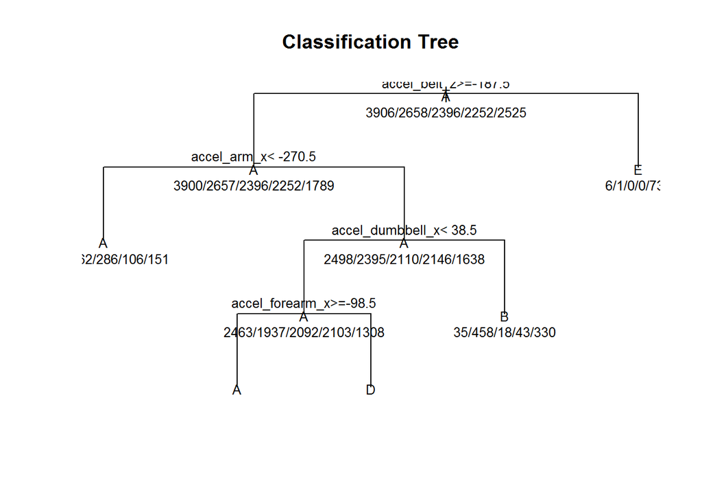

```r
plot(modFit$finalModel, uniform=TRUE,
    main="Classification Tree")
    text(modFit$finalModel, use.n=TRUE, all=TRUE, cex=.8)
```

```r
pred <- predict(modFit,newdata=testParamD)
decisionTreeCm <- confusionMatrix(pred, testParamD$classe)
decisionTreeCm
```

```
## Confusion Matrix and Statistics
##
##           Reference
## Prediction    A    B    C    D    E
##          A 1321  673  724  301  398
##          B   15  184   12   15  142
##          C    0    0    0    0    0
##          D  338  282  290  648  250
##          E    0    0    0    0  292
##
## Overall Statistics
##
##                Accuracy : 0.4155
##                  95% CI : (0.4028, 0.4282)
##     No Information Rate : 0.2845
##     P-Value [Acc > NIR] : < 2.2e-16
##
##                   Kappa : 0.2342
##  Mcnemar's Test P-Value : NA
##
## Statistics by Class:
##
##                      Class: A Class: B Class: C Class: D Class: E
## Sensitivity            0.7891  0.16155   0.0000   0.6722  0.26987
## Specificity            0.5023  0.96123   1.0000   0.7643  1.00000
## Pos Pred Value         0.3866  0.50000      NaN   0.3584  1.00000
## Neg Pred Value         0.8570  0.82690   0.8257   0.9225  0.85875
## Prevalence             0.2845  0.19354   0.1743   0.1638  0.18386
## Detection Rate         0.2245  0.03127   0.0000   0.1101  0.04962
## Detection Prevalence   0.5806  0.06253   0.0000   0.3072  0.04962
## Balanced Accuracy      0.6457  0.56139   0.5000   0.7182  0.63494
```

# Bagging Algo

We will build the bagging model using bag function in caret package.

```r
# model using bag algo
predictors = data.frame(paramD[,1:16])
#install.packages("party")
treebag <- bag(predictors, paramD$classe, B = 10, vars = ncol(predictors),
            bagControl = bagControl(fit = ctreeBag$fit,
            predict = ctreeBag$pred,
            aggregate = ctreeBag$aggregate))
bagPred <- predict(treebag,testParamD[,1:16])
bagCm <- confusionMatrix(bagPred, testParamD$classe)
bagCm
```

```
## Confusion Matrix and Statistics
##
##           Reference
## Prediction    A    B    C    D    E
##          A 1517   96   41   83   10
##          B   33  916   64   22   50
##          C   62   68  885   60   28
##          D   55   18   26  778   31
##          E    7   41   10   21  963
##
## Overall Statistics
##
##                Accuracy : 0.8596
##                  95% CI : (0.8505, 0.8684)
##     No Information Rate : 0.2845
##     P-Value [Acc > NIR] : < 2.2e-16
##
##                   Kappa : 0.8222
##  Mcnemar's Test P-Value : 2.035e-10
##
## Statistics by Class:
##
##                      Class: A Class: B Class: C Class: D Class: E
## Sensitivity            0.9062   0.8042   0.8626   0.8071   0.8900
## Specificity            0.9454   0.9644   0.9551   0.9736   0.9836
## Pos Pred Value         0.8683   0.8442   0.8024   0.8568   0.9242
## Neg Pred Value         0.9621   0.9535   0.9705   0.9626   0.9754
## Prevalence             0.2845   0.1935   0.1743   0.1638   0.1839
## Detection Rate         0.2578   0.1556   0.1504   0.1322   0.1636
## Detection Prevalence   0.2969   0.1844   0.1874   0.1543   0.1771
## Balanced Accuracy      0.9258   0.8843   0.9089   0.8903   0.9368
```

# Model using Random Forest algo

During the training of Random Forest model,I noticed it took a lot of time to generate the model. So I created the model once and saved it using saveRDS fucntion into the working directory. It can be loaded later while doing a prediction

rfFit <-train( classe ~ .,data=paramD,method=“rf”,prox=TRUE, eval=FALSE) saveRDS(rfFit, file=“rfModel.rds”)

```r
rfFit = readRDS("rfModel.rds")

#Run the prediction on test data
valpred <- predict(rfFit,newdata=testParamD)

rfModelCm <- confusionMatrix(valpred, testParamD$classe)
rfModelCm
```

```
## Confusion Matrix and Statistics
##
##           Reference
## Prediction    A    B    C    D    E
##          A 1655   20    2   13    0
##          B    2 1107   11    2    5
##          C   10    8 1012   16    4
##          D    7    3    1  933    2
##          E    0    1    0    0 1071
##
## Overall Statistics
##
##                Accuracy : 0.9818
##                  95% CI : (0.9781, 0.9851)
##     No Information Rate : 0.2845
##     P-Value [Acc > NIR] : < 2.2e-16
##
##                   Kappa : 0.977
##  Mcnemar's Test P-Value : NA
##
## Statistics by Class:
##
##                      Class: A Class: B Class: C Class: D Class: E
## Sensitivity            0.9886   0.9719   0.9864   0.9678   0.9898
## Specificity            0.9917   0.9958   0.9922   0.9974   0.9998
## Pos Pred Value         0.9793   0.9823   0.9638   0.9863   0.9991
## Neg Pred Value         0.9955   0.9933   0.9971   0.9937   0.9977
## Prevalence             0.2845   0.1935   0.1743   0.1638   0.1839
## Detection Rate         0.2812   0.1881   0.1720   0.1585   0.1820
## Detection Prevalence   0.2872   0.1915   0.1784   0.1607   0.1822
## Balanced Accuracy      0.9902   0.9838   0.9893   0.9826   0.9948
```

# Conclusion